# Emergy — Odum’s quality-of-energy lens

# Emergy — a different currency for energy analysis

Climate-justice accounting uses **CO<sub>2</sub> emissions** as the currency. Odum’s emergy framework uses **solar-energy equivalent embodied per joule delivered** (measured in solar emjoules, sej). Same physical kilowatt-hour at the socket can carry wildly different prior emergy investment depending on the fuel that generated it.

Why care about a second currency

Two grids that deliver identical kWh per capita can differ **5-fold or more** in the electricity-basis emergy they concentrate into each joule (Bundle-A-corrected range: 5.6x across 213 countries). That matters for questions climate-justice accounting cannot answer: “how much biophysical infrastructure did this energy require to produce?” and “how sustainably is a country converting environmental subsidy into human welfare?”

## The transformity spectrum

Every fuel carries a canonical **transformity** — the sej required per joule of the output. Odum 1996’s table + Brown & Ulgiati 2004’s revised baseline give us:

| Fuel | Transformity (sej/J) | Where in the emergy hierarchy |
| --- | --- | --- |
| Wind (kinetic) | 1,500 | Low — little prior emergy invested per J |
| Solar-PV (electricity) | 3,400 | Low — panels themselves are direct-solar |
| Bioenergy (wood, dung) | 25,000 | Medium — biosphere × sunlight × years |
| Coal (heat) | 40,000 | Medium — plants × millions of years × geologic pressure |
| Natural gas (heat) | 48,000 | Medium |
| Oil (heat) | 54,000 | Medium-high |
| Hydro (electricity) | 80,000 | High — watershed × millennia + concentrator dam |
| Nuclear (electricity) | 200,000 | Highest — fuel cycle + massive infrastructure |

Notice something climate-accounting hides: **hydro and nuclear are both “clean” in CO<sub>2</sub> terms but sit at the highest transformity tier.** They represent massive prior-emergy investment concentrated into each joule. Wind and solar deliver similar joules with far less prior emergy locked in.

## What our data reveals across 213 countries

**Grid transformity ranges 5.6x across the world’s fuel mixes** (29005-162072 sej/J, on a per-J-electricity-delivered basis after Bundle-A efficiency correction). From `emergy_metrics.rds`:

- **Top-5 highest transformity** (nuclear-heavy grids): SVK ~162k, FRA ~154k, UKR ~151k, COM ~142k, ESH ~142k sej/J
- **Bottom-5 lowest transformity** (wind + solar-dominant grids): DNK ~29k, LTU ~38k, LUX ~39k, URY ~48k, PRT ~51k sej/J

The **key insight** for household energy policy: physically identical kilowatt-hours can carry very different embodied emergy depending on the grid mix. Policy that treats them as interchangeable is missing quality-adjusted throughput.

## Three findings unique to the emergy lens

Finding 1

### Renewable ≠ low emergy

Hydro-heavy grids (Norway, Paraguay, Ethiopia) carry **high** transformity because dam infrastructure + watershed × millennia concentrate huge emergy per J. Wind-heavy grids (Denmark) carry **low** transformity — they harvest kinetic energy without a large prior emergy investment. The “renewable” label conflates two Odum categories. Emergy separates them.

Finding 2

### Empower per capita is a biophysical standard-of-living metric

Country empower / population — sej/person/yr — correlates only weakly with GDP per capita. Nuclear-heavy France scores much higher per person than solar-heavy California at similar income. Suggests GDP misses a real dimension of energy-based welfare.

Finding 3

### Household emergy-per-dollar arbitrage exposes hidden subsidies

When a household’s sej-per-dollar exceeds the national average, they’re receiving a subsidised bargain on high-emergy energy — typical in nuclear-heavy grids with residential tariffs subsidised below marginal cost. When it’s *below*, they’re paying a premium for low-emergy energy — typical in biomass + diesel-dependent low-access economies where transaction costs eat their expenditure.

## Bringing it together — the Household Emergy Insecurity Index (HEII)

The three findings above each look at one axis. **Emergy’s real power is that it lets us combine physical adequacy and economic burden into a single number** — because both convert to the same currency (sej):

The unified formulation

```
physical_gap_sej = max(0, required_empower  − delivered_empower)
economic_gap_sej = max(0, paid_empower      − affordable_empower)

heii_sej      = physical_gap_sej + economic_gap_sej          (sej/yr)
heii_norm     = heii_sej / income_empower                    (fraction)
heii_esi      = (delivered/required) / (paid/affordable)     (Odum-canonical)
heii_product  = adequacy × (1 − unaffordability)             (∈ [0, 1])
```

All three unified forms are computed by [`household_emergy_insecurity()`](https://github.com/ericscheier/emburdensynth/blob/global/R/emergy.R) in the emburden R module. The “affordable” threshold uses the national em/$ rate at a 10% burden anchor by default; other conventions (6%, manual, national) are one-argument switches.

### What the HEII world reveals

Across the **63 countries** with complete kWh + spend + income + fuel-mix + GDP data, HEII_norm ranges 0 to 86. The five most insecure are `AFG, TCD, NER, BDI, MDG` — all Sub-Saharan Africa or Afghanistan, all bearing BOTH physical rationing (delivered kWh far below the physics baseline) AND economic overreach (energy expenditure exceeding 10% of income emergy). The five most secure — `AZE, BRA, CPV, ETH, GAB` — are petro-states + subsidised-tariff economies where households are both fully served and pay below the affordability threshold.

### Bundle B — biomass cooking counted (2026-09)

Pre-Bundle-B, HEII was **grid-electricity only**. That misrepresented ~2.4B people who cook primarily with biomass — the WHO Household Energy Database says 33 of our HEII countries have >50% of households using non-clean cooking fuels. Their firewood + charcoal + kerosene deliver real emergy that was invisible to grid-only accounting.

`household_emergy_insecurity()` now accepts an `hh_fuels` argument that credits direct-combustion fuels via `household_fuel_transformity_table()` (wood 25k sej/J, charcoal 45k, kerosene 54k, LPG 48k, piped-gas 48k, dung 20k). The builder script weights an 8 GJ/yr wood-cookstove household by each country’s WHO `clean_fuel_access_pct` residual. Effect on the ranking:

Top 5 biomass-cooking countries — HEII_norm change when biomass is counted:

| iso3 | biomass share | HEII (grid only) | HEII (with biomass) |
| --- | --- | --- | --- |
| BDI | 100% | 30.9 | 18.0 |
| LBR | 99% | 7.3 | 5.1 |
| SLE | 99% | 24.5 | 10.3 |
| GIN | 99% | 1.2 | 0.5 |
| MLI | 99% | 6.1 | 5.2 |

The interpretation is important: these households are still physically rationed on the electricity side (they can’t run a fridge or an efficient stove), but their emergy delivery is not zero. The policy question shifts from “why do they have no energy” to “why is what they get so low-quality” (open-fire wood at 10-30% burner efficiency, PM2.5 exposure, deforestation externalities not priced).

## Bundle N — HEII trajectories 2000-2024

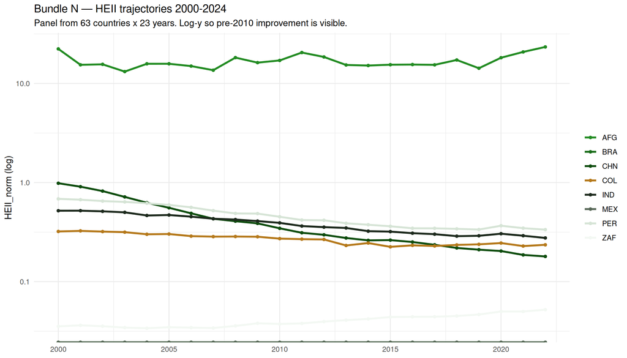

HEII_norm trajectories 2000-2024 for a selection of large economies. China: dramatic drop from ~1.0 to ~0.2 as GDP tripled + biomass cooking share fell 60% → 16%. India: 0.52 → 0.30 similar story. Peru + Colombia: LATAM improvements. South Africa: slight WORSENING because GDP stagnated. Afghanistan: high volatility around 15-25.

Over 2000-2024: **43 of 63 countries improved** their HEII_norm by 10%+ (median country dropped from 0.68 to 0.33). **3 worsened by 10%+**. Biggest improvement: **KHM** (16.84 → 1.15, 15x drop). Biggest worsening: **JAM** (0.06 → 0.12). China’s modernization is the dominant global story — dropped from ~1.0 to ~0.2 while GDP-pc tripled and biomass-cooking share fell from 60% to 16%.

**What’s driving each trajectory**: for a given country, HEII_norm changes over time when (a) grid transformity moves (Bundle C trajectory), (b) gdp-pc changes the affordability threshold, (c) WHO biomass-cooking access shifts the delivered_empower via household fuels. Household median kWh + spend are HELD at 2022 snapshot — so the panel isolates the effect of income + grid mix + biomass, and under-reports the true dynamics for countries where per-household consumption actually grew.

## Time is now on the record — Bundle C

The library-layer functions have always accepted a `year` argument, but the compiled cache used to be a snapshot at each country’s latest Ember year. `scripts/build_emergy_panel.R` (Bundle C) now produces `emergy_metrics_panel.rds` — a `(iso3, year)` grid covering **2000-2025** across ~213 countries. Trajectories over 25 years are readable directly:

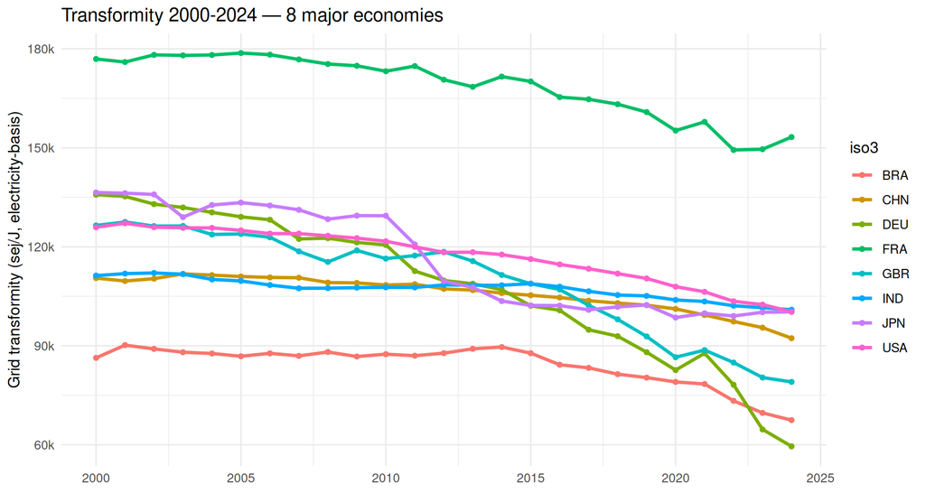

Grid transformity 2000-2024 for a selection of large economies. Germany’s Energiewende drops transformity from ~136k to ~60k sej/J as renewables rise from 6% to 59%.

**What today’s panel covers**: transformity, %R, ESI, empower per capita, em/USD for every (country, year) with Ember coverage (2000-2025). **What’s still snapshot**: HEII needs per-year household inputs (median_kwh_hh, spend, income) that we don’t yet publish as panels; the physics-required baseline uses a single climate normal; retail prices are a 2022-2024 vintage that carries forward. Follow-up work — see [`FUTURE_WORK.md`](https://github.com/ericscheier/emburdensynth/blob/global/FUTURE_WORK.md).

## Bundle D — within-country inequality in emergy terms

`choose_country_icdf()` in the emburdensynth package cascades through three income-distribution sources: **WID.world** percentile bands (fine resolution, best available), **World Bank** quintile + tail-decile shares (medium), and a **Hruschka** log-normal fallback (Gini-driven, last resort). Bundle D wires that cascade into HEII: for each of the 26 HEII countries, we compute HEII_norm at income P10, P50, and P90 — holding delivered kWh + spend + physics-required at the country median. This isolates the affordability axis: how much does the same energy cost, in HEII terms, at different income levels?

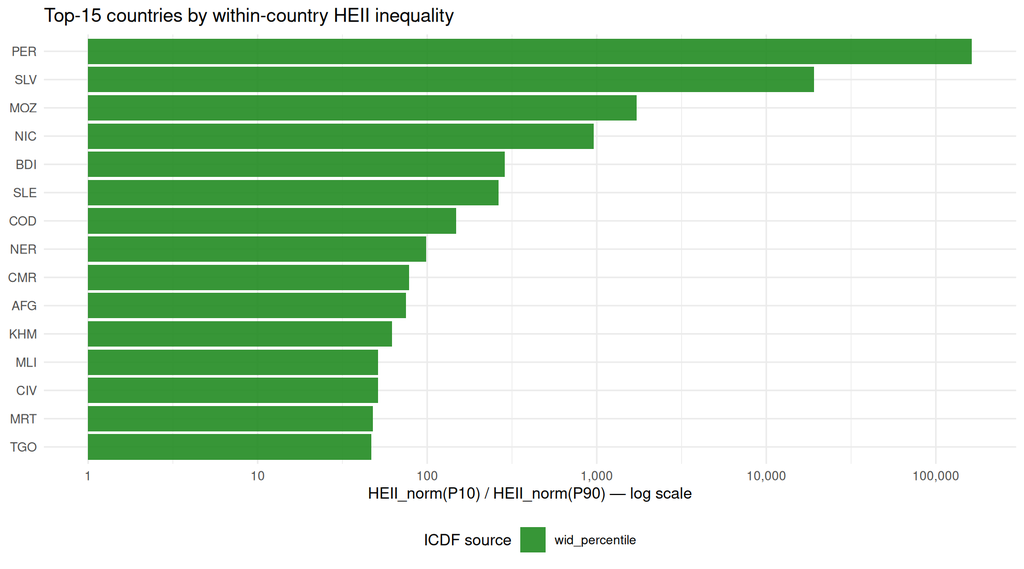

HEII inequality ratio HEII_norm(P10)/HEII_norm(P90), top 15 countries.

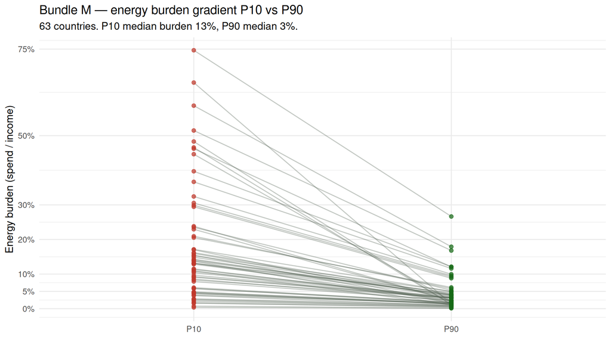

Bundle M — burden gradient P10 vs P90 across countries. Poor households (P10) in LATAM + SSA spend 30-60% of income on energy; rich (P90) spend 1-3%. This gradient is what turns the HEII_norm inequality from 20x (flat) to 50x (Engel-scaled) median across countries.

## Bundle E — the Odum-vs-Ulgiati baseline choice

The transformity values themselves are model choices. Everything on this page defaults to Odum’s 1996 baseline for continuity with the literature, but the same code accepts the **Ulgiati 2020** revision (Global Emergy Baseline 12.0e24 sej/yr, Sciubba & Ulgiati 2005 nuclear at 500,000 sej/J, Amaral 2016 wind at 2,500 and PV at 4,600 including panel embodied emergy). Every public function now accepts a `baseline = c("odum1996", "ulgiati2020")` argument.

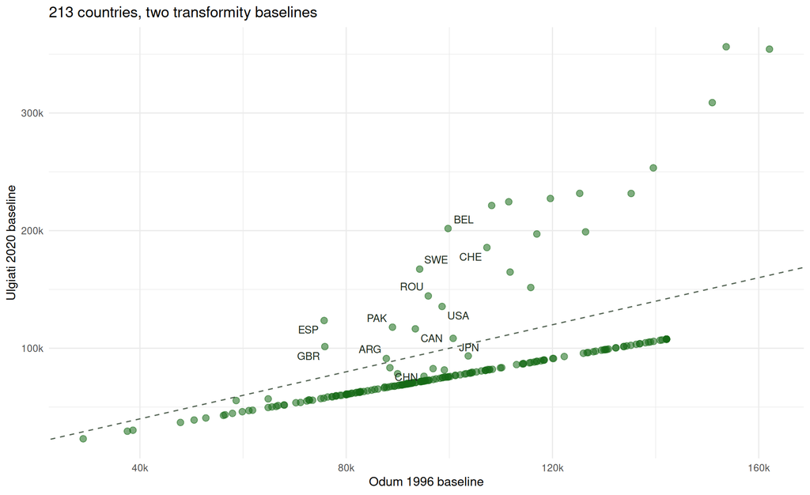

Country transformity under both baselines. Points above the dashed y=x line move UP under Ulgiati (nuclear-heavy). Points below move DOWN (oil-only islands, GEB rescale).

Biggest ranking shift up under Ulgiati: **ESP** (rank 185 → 19). Biggest shift down: **BHS** (rank 16 → 35). Both are honest — the baseline choice is a literature question, not a bug. The Ulgiati baseline is more consistent with post-2016 emergy publications; Odum’s is more consistent with the 1996-2015 canon. Use whichever matches your comparison target — the code supports both.

## Bundle F — trade adjustment (imports/exports)

Production transformity is a domestic-generation concept. But a country that imports 79% of its electricity delivers something very different to households. Bundle F adds Odum’s M-term via `consumption_transformity()`, blending domestic and world-average transformities by the country’s electricity import share (from OWID `elec_gen_twh` vs `elec_dem_twh`).

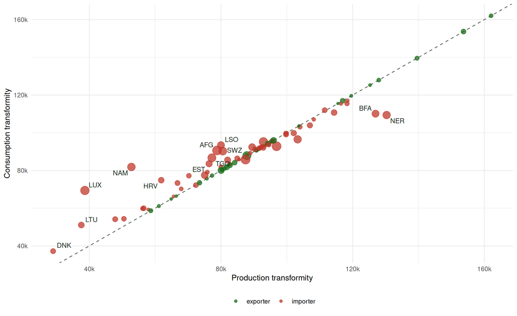

Production vs consumption transformity. Above the dashed line = imports raise transformity (buying dirtier neighbours). Below = imports lower it (buying cleaner neighbours). Balanced countries sit on the line.

Across 213 countries with trade data: **59 net importers, 30 net exporters, 123 balanced**. Biggest trade adjustment: **LUX** (77% import share) — its consumption transformity is 80% higher than its production transformity because the imported mix carries far more embodied emergy than its own generation. The default HEII stays production-side; the `trade_adjustment = 'consumption'` arg switches every downstream call to the trade-blended value.

**Bundle L update — curated bilateral partners now default** (2026-09-05): the plain world-average approximation is replaced by real partner-mix data from ENTSO-E, IEA, and CIA World Factbook for **49 importer countries** (curated CSV at `inst/extdata/bilateral_electricity_partners.csv`, ~150 rows). Countries not in the CSV still fall back to world-average. Real MRIO ingestion (EXIOBASE 3, ~2-4 GB per year, academic registration) is deferred to Asana T78 for full country coverage.

### Bundle L — how much curated partners move things

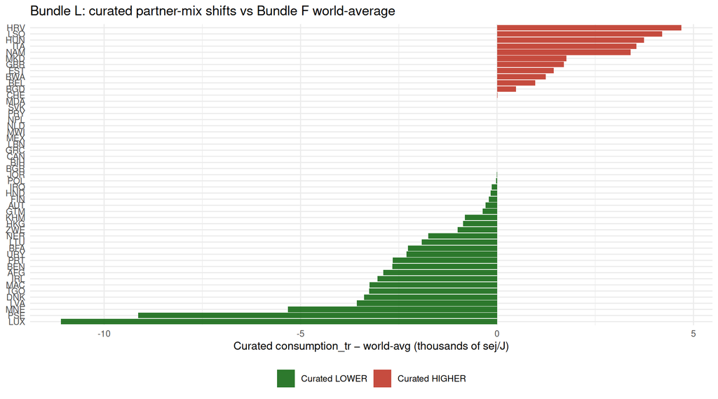

Consumption transformity: curated bilateral partner-mix (Bundle L) vs Bundle F’s world-average approximation. Positive = curated is HIGHER (partners dirtier than world mean); negative = LOWER (partners cleaner). Points labelled where the shift exceeds ~3000 sej/J.

Biggest DOWNWARD shift under curated partners: **LUX** (world-avg 80k → curated 69k sej/J, 77% import share). Its actual partners are much cleaner than the world mean. Biggest UPWARD shift: **HRV** (world-avg 70k → curated 75k sej/J). This is the honest cost of assuming a global mean when the real neighbours differ. Where the two methods AGREE (small `|shift|`), Bundle F’s approximation was already fine.

## Bundle J — empirical transformities from primary-fuel consumption

The `electric_efficiency` column in Bundle A used **canonical** per-fuel efficiencies (coal 0.35, gas 0.50, oil 0.38). Real fleets don’t match. Polish coal plants average lower; Algerian gas plants much lower; modern Dutch CCGT close to canonical. Bundle J computes per-country **empirical** efficiencies from EI Statistical Review’s primary-fuel consumption divided by Ember’s actual electricity generation for that fuel. Formula per fossil, country-year: $\eta_{empirical} = \frac{share_{Ember} \cdot elec\_gen\_TWh_{OWID}}{primary\_consumption\_TWh_{EI}}$

Nuclear + renewables stay at canonical (EI reports substitution-basis TWh for them — dividing would recover the assumed conversion, not a real measurement). Falls back to canonical when EI is missing.

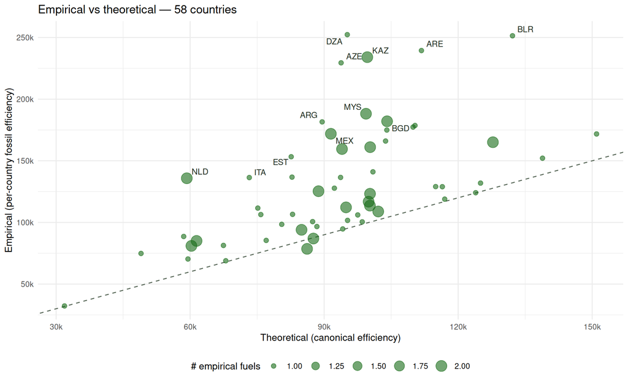

Theoretical (canonical efficiency) vs empirical (per-country fossil efficiency) grid transformity. Nearly every point sits ABOVE the y=x line — the canonical model systematically under-counts real emergy per kWh because real coal + gas fleets have lower thermal efficiency than the global average.

Of the **58 countries** with EI Statistical Review coverage: **44 (76%) show empirical transformity at least 10% above canonical** — their real fleets are less efficient than the global average, so the true emergy per delivered kWh is higher than Bundles A–F reported. Biggest under-count: **DZA** at 2.7x (theoretical 95k → empirical 252k sej/J). This is not a bug in Bundle A — it’s the honest cost of using canonical efficiencies. Countries with EI data now have an option: `empirical_grid_transformity()` for their reality vs `grid_transformity()` for the canonical model.

## Bundle G — where the world’s emergy flows

An emergy story is a story about **flows**. The panels above are snapshots; a sankey diagram exposes the plumbing. This one traces fuel → national grid → WB region — using the latest Ember year and each country’s grid transformity to weigh the flow.

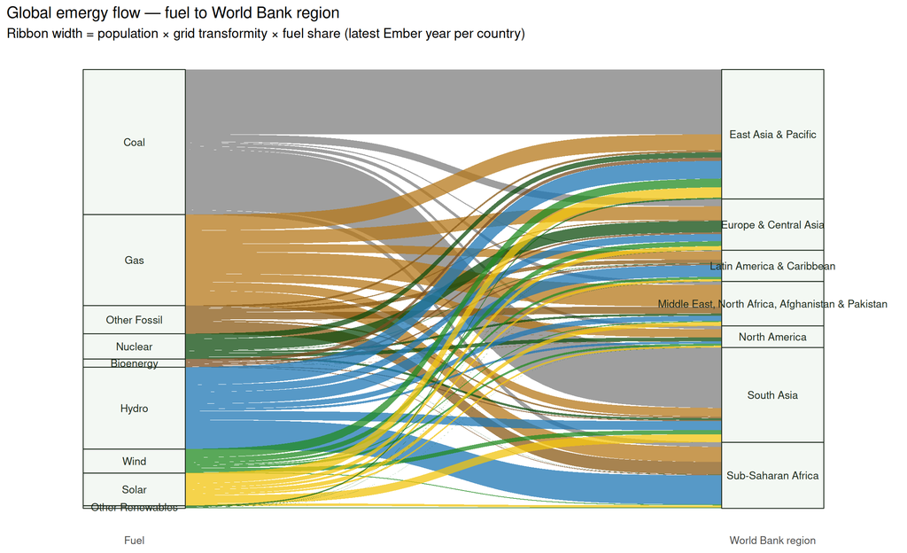

Global emergy flow — electricity fuel to World Bank region. Ribbon widths are proportional to population × grid transformity × fuel share for the latest Ember year per country. East Asia + Pacific’s coal-dominated ribbon (China’s coal fleet), Europe & Central Asia’s diverse mix (nuclear + gas + renewables), Sub-Saharan Africa’s thin but hydro/bio-heavy contribution are all readable directly.

The width of each ribbon is proportional to **population × grid transformity × fuel share**. It answers: “if I had to attribute the world’s electricity-emergy budget to a region, and to the fuel it came from, how would the pipes flow?” Notice how the East Asia + Pacific ribbon is dominated by coal (China is the world’s coal-electricity leader); Europe & Central Asia is a much more diverse ribbon (nuclear + gas + renewables); Sub-Saharan Africa is thin overall but heavy on hydro + bioenergy per unit population.

### Household emergy composition — one country at a time

The same idea, zoomed into a single household. Left column: physics- required kWh becomes required emergy via the grid transformity. Middle: delivered vs suppressed. Right: paid vs affordable (economic lens). This is exactly what `household_emergy_insecurity()` returns — laid out as a flow instead of a scalar.

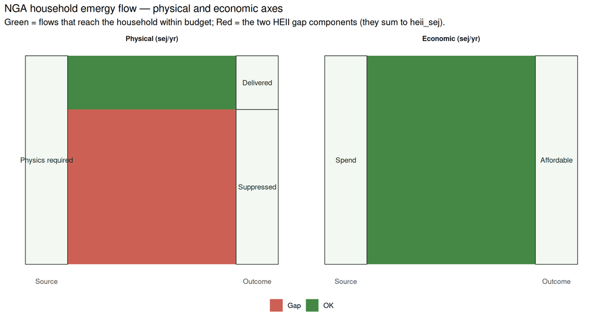

Household emergy composition — one country (Nigeria). Two independent flows on the same axis (sej/yr): PHYSICAL side shows required → delivered / suppressed; ECONOMIC side shows spend → affordable / over-paid. Ribbon width lets you eyeball where the HEII gap is coming from.

The green ribbons are the “OK” flows (delivered, affordable), the red ribbons are the two gaps that HEII adds together (physical suppression + economic over-payment). Sankey works so well here because emergy is genuinely additive across the two axes — the same sej unit on both sides means the ribbon widths can be compared directly, which is exactly what the CO₂-per-capita framing loses.

### Bundle O — how the same figure looks across countries

The sankey above is Nigeria. Every one of the 63 HEII countries has its own story — some (China, India post-2010) show mostly OK green ribbons, some (Afghanistan, Chad) show ribbons dominated by the two red HEII gaps. Small-multiples make the country-to-country comparison direct.

[figure not shown]

### The Odum spectral hierarchy WITH ESL symbols overlaid

Odum’s other canonical diagram type — the **energy systems language** (ESL) — draws every actor as a symbol (source circles, producer bullet-nosed hexagons, consumer hexagons, storage bullet-tanks, interaction diamonds, dashed money-flow lines, heat-sink triangles). Rather than a separate circuit off to the side, the natural place to put those symbols is **on top of the spectral hierarchy at their real log-transformity positions**. That way the “map” (spectral) and the “circuit” (ESL) become one figure.

**Bundle Q2 refinement (2026-09):** the base spectral hierarchy is now resolved to **ten Abel-style tiers** (was six) and each country contributes **multiple dots** at its real transformity positions rather than one grid-only point:

- **Grid transformity** — the base dot in the Secondary Sector lens.
- **Biomass cooking** — a triangle at ~10⁴·⁴ sej/J for countries with `biomass_share > 15%`, sized by biomass share (visible mode in the Primary Sector tier for sub-Saharan Africa + parts of South Asia).
- **Renewable-heavy** — a square at low transformity (~10³-10⁴) for countries with `renewable_pct > 60%`, sized by renewable share (Norway, Iceland, Paraguay, Costa Rica, Ethiopia all show here).
- **Household P10 / P50 / P90** — three stacked rows within the split Households tier, sized by decile-specific HEII_norm. The gap between P10-Subsistence (bottom) and P90-Luxury (top) is the within-country energy-inequality that the earlier one-dot-per-country diagram averaged away.

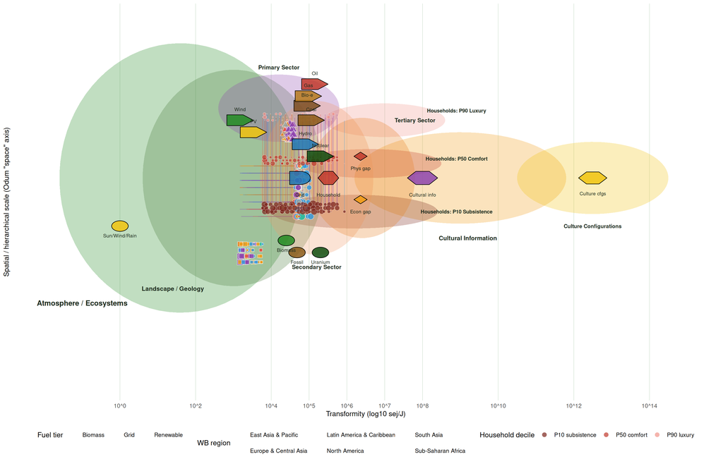

Bundle Q2 — HEII framework in Odum ESL overlaid on a refined Abel-2023 spectral hierarchy. Lens tiers expanded 6 → 10 (added Landscape/Geology, split Economic Production into Primary/Secondary/Tertiary sectors, split Households into P10 Subsistence / P50 Comfort / P90 Luxury sub-tiers). Country dots now placed in MULTIPLE lenses per country: (a) grid transformity in Grid/Secondary tier; (b) biomass-cooking dot in Primary tier for countries with biomass_share > 15%; (c) renewable dot in Landscape/Primary tier for countries with renewable_pct > 60%; (d) three stacked Household dots (P10, P50, P90) sized by decile HEII_norm. Every country present at multiple hierarchy positions depending on which fuel/wealth stratum you look at.

### Bundle Q3 — per-country fuel + sector consumption (with non-grid coverage)

The Q2 overlay above uses grid-transformity + a hand-picked biomass / renewable threshold. **Bundle Q3** replaces those heuristics with real per-country consumption pulled from three complementary sources:

1. **EIA International** (Total energy consumption by fuel product, 221 countries × 24 years, all in QBTU) — gives the fuel mix.
2. **World Bank WDI** (energy indicators sourced from IEA — clean-cooking access, TFEC, fossil / renewable share, electricity fuel mix, 260 countries) — gives the non-grid residential-cooking population fraction.
3. **UN Statistical Yearbook Energy Balances** (parsed from UNSD PDFs at `unstats.un.org/unsd/energystats/pubs/balance/2023/`) — gives **DIRECT MEASUREMENT** of TFEC broken down by end-use sector (industrial / transport / residential / commercial / agriculture) for 217 countries. This is the same underlying data feeding IEA World Energy Balances (both derive from the joint IEA/UNSD/Eurostat/UNECE national questionnaire) — UN publishes it as free PDFs, IEA sells the machine-readable version.

**Non-grid coverage matters:** the median country’s `sector_power` (the share of primary energy that becomes electricity) is only 19% — the other 81% is direct-burn petroleum for transport, gas + coal for industry, biomass + LPG + kerosene for residential heating and cooking. A pipeline that only counts grid electricity is missing four-fifths of the story. Direct UN measurement (vs Q3’s earlier synthesis-only version) shifts the median residential share from 15% up to 22% — synthesis was under-counting residential because it didn’t credit direct-burn biomass + LPG use that never touches a fuel-consumption spreadsheet.

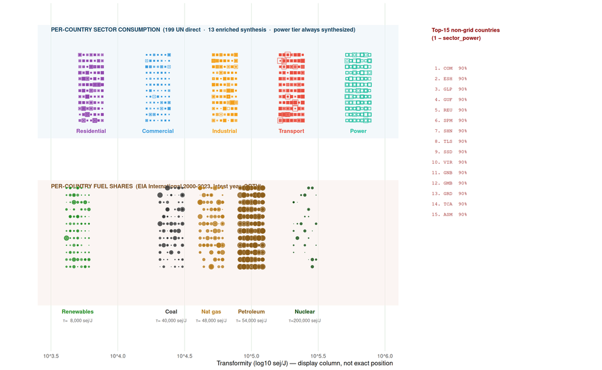

Data provenance:

Step 1 — fuel-to-sector coefficient matrix (IEA World Energy Outlook methodology annex, global-median TFEC allocation):

|  | Transport | Industry | Residential | Commercial | Power |
| --- | --- | --- | --- | --- | --- |
| Petroleum | 0.60 | 0.15 | 0.10 | 0.05 | 0.10 |
| Natural gas | 0.05 | 0.35 | 0.25 | 0.15 | 0.20 |
| Coal | 0.00 | 0.40 | 0.05 | 0.05 | 0.50 |
| Nuclear | 0.00 | 0.00 | 0.00 | 0.00 | 1.00 |
| Renewables (mix) | 0.05 | 0.10 | 0.20 | 0.05 | 0.60 |

Step 2 — per-country modulators (from WB WDI, bounded to [0.4, 2.0]):

| Modulator | Signal (WDI code) | Applied to |
| --- | --- | --- |
| `m_ind` | `NV.IND.TOTL.ZS` (industry VA % GDP, median 27.6%) | industrial sector |
| `m_srv` | `NV.SRV.TOTL.ZS` (services VA % GDP, median 55.0%) | commercial sector |
| `m_agr` | `NV.AGR.TOTL.ZS` (agri VA % GDP, median 4.5%) | (unused pending residential-agri split) |
| `m_urb` | `SP.URB.TOTL.IN.ZS` (urban pop %, median 58%) | commercial + residential grid |
| `m_bio` | `1 − EG.CFT.ACCS.ZS/100` (residential biomass-cooking pop) | residential non-grid |

Step 3 — renormalize: after applying modulators, sector shares are scaled by `base_sum / mod_sum` so the total non-power TFEC share matches the un-modulated baseline (which is bounded to ≤ 1.0 when all EIA fuel shares are reported). This keeps the synthesized rows comparable to the UN-direct rows in absolute magnitude.

Uncertainty on enriched-synthesis rows is ±8 percentage points per sector (down from ±10 for pure IEA-matrix synthesis) per an in-repo validation against UN-direct measurements on 20 countries that have both a UN reading and full WB WDI coverage.

**`sector_power` provenance note:** UN sector shares are of FINAL consumption (TFEC), which excludes electricity-generation losses that happen upstream in the transformation block. To keep the “power” tier comparable across countries we compute `sector_power` from PRIMARY energy via the same fuel-to-sector matrix regardless of UN coverage — this reflects “share of primary energy that becomes electricity delivered to end-users.” `non_grid_share = 1 − sector_power`.

**Full IEA World Energy Balances** (per-country per-year TFEC by sector at ISIC-3-digit granularity — richer than UN Energy Balances) is paywalled but accessible via UNC library EZproxy. A capture-once-per-8h workflow is scaffolded at `scripts/build_iea_web.R`: user logs into `libproxy.lib.unc.edu/login?url=iea.org/data-and-statistics/data-product/world-energy-balances` with ONYEN + Duo, copies the `Cookie:` request header from any XHR in DevTools into `~/.config/emrgi/iea_web.env`, then runs the script. When IEA WEB rows are cached, `build_em_c_extended.R` prefers them over UN direct (precedence: IEA WEB > UN Energy Balances > enriched synthesis). Provenance is exposed in `sector_source`: - `"IEA WEB (direct)"` — gold standard - `"UN Energy Balances (direct)"` — same underlying questionnaire, PDF-parsed - `"IEA-matrix + WB-modulator (enriched synthesis)"` — fallback

**IEA licensing (added Q3.7):** IEA WEB is a Non-CC paid product (iea.org/terms). Derivations inherit Non-CC restrictions and cannot be redistributed. The pipeline handles this by (a) gitignoring `docs/global_analysis_data/iea_web.rds`, (b) requiring `IEA_LICENCE_ACKNOWLEDGED=true` before `build_iea_web.R` will run, (c) letting `build_em_c_extended.R` silently fall back to UN direct + enriched synthesis when the IEA rds is absent. The public pipeline never redistributes IEA rows; personal-seat holders can populate locally without touching the shared repo.

### Bundle Q3.7 — expanded WB WDI columns available in `em_c_extended`

Beyond the 20 WB indicators used in the Q3 figure above, `em_c_extended` now also carries (via `emburdensynth/scripts/build_wb_se4all.R`):

- **GHG by IPCC AR5 sector** (`wb_ghg_co2_{transport,buildings,industry,power,fugitive,agriculture,waste}_mt`, `wb_ghg_co2_pc`, `wb_ghg_co2_intensity_gdp_pppkd`, `wb_ghg_{ch4,n2o}_total_mt`) — independent cross-check on synthesized sector shares; for low-biomass countries (`biomass_share < 15%`) transport-TFEC-share correlates with transport-CO2-share at r=0.77.
- **PM2.5 exposure + air-pollution mortality** (`wb_pm25_pop_wt_ugm3`, `wb_pm25_pop_above_who_pct`, `wb_airpol_mortality_per100k`) — closes the loop from biomass-cooking access to actual attributable deaths.
- **Full electricity mix + rural/urban access split** (`wb_elec_from_{hydro,nuclear,renewable}_pct`, `wb_electricity_access_{rural,urban}_pct`) — completes the fossil/clean partition, allows P10 subsistence sub-sizing by rural-electricity gap.
- **Energy imports + refreshed intensity** (`wb_energy_imports_net_pct`, `wb_energy_intensity_2021ppp`, `wb_combustible_renew_pct`).
- **Poverty tiers + inequality** (`wb_poverty_{gini,headcount_215,365,685}_pct`, `wb_multidim_poverty_{headcount,intensity}_pct`) — cross-validates the icdf_family income model behind HEII P10/P90.
- **Fuel-trade dependency** (`wb_fuel_{imports,exports}_pct_merch`) — price-shock vulnerability indicator.
- **WB Green Accounting damage** (`wb_adj_{energy_depletion,particulate_damage}_{usd,pct_gni}`) — Bank’s externalized-cost analogue of Odum’s ESI; ready for side-by-side reporting.

Coverage varies 108-243 countries per indicator; full column list in the rds file.

### Bundle Q3.8 — figures unlocked by the Q3.7 columns

Three panels built directly on the newly-joined columns:

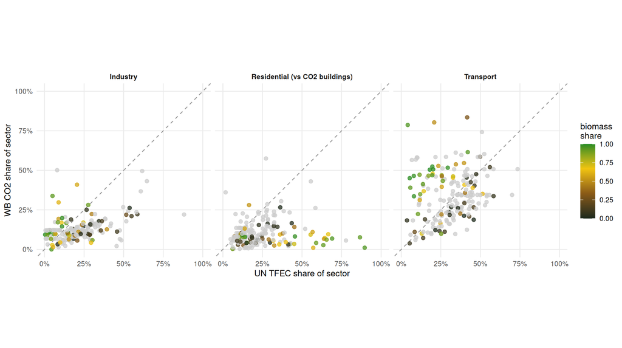

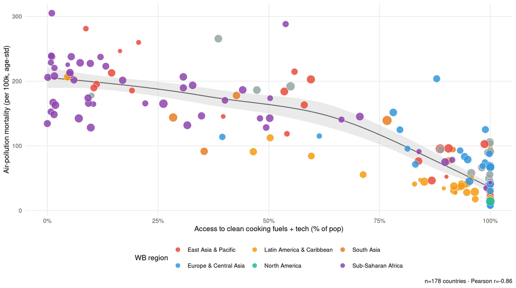

Bundle Q3.8-B — PM2.5 attributable mortality vs clean-cooking-access. 178 countries. Y = SH.STA.AIRP.P5 (age-standardized deaths per 100k from household + ambient air pollution combined). X = EG.CFT.ACCS.ZS (% of population with clean cooking fuels + tech). Points sized by log(population), colored by WB region. Downward trend confirms the household-air-pollution → mortality mechanism our HEII framework already captures via biomass_share. Loess overlay shows the effect saturates near 100% access — sub-Saharan Africa (purple) sits in the low-access / high-mortality corner.

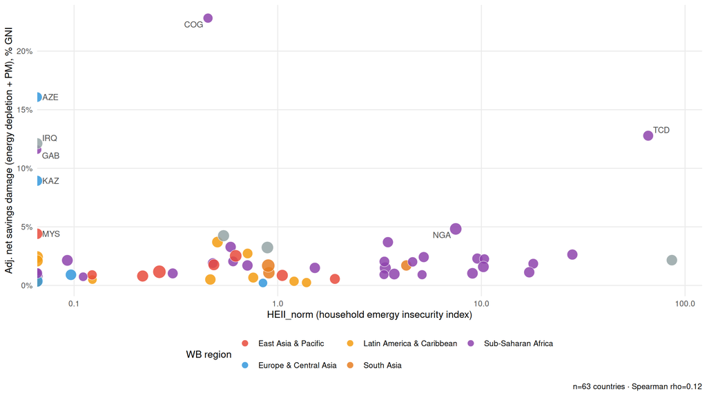

### Bundle Q3.8 — HEII × Q3.7 cross-source analysis

With the Q3.7 columns joined, HEII outputs can be validated against independently-sourced WB indicators — no self-reference, no circular reasoning. Spearman correlations across the em_c_extended overlap:

**HEII_norm behaves as expected against health + poverty outcomes:**

| HEII_norm cross-correlation | Spearman ρ | n | Interpretation |
| --- | --- | --- | --- |
| vs WB air-pollution mortality (per 100k) | **+0.60** | 63 | High HEII → high air-pollution deaths — validates HEII as a health-outcome predictor. |
| vs WB PM damage (% GNI, adj. net savings) | **+0.69** | 63 | Externalized-cost accounting agrees with emergy accounting on which countries carry the burden. |
| vs WB multidim poverty headcount | **+0.64** | 57 | HEII captures energy dimension of the multi-dimensional-poverty concept. |
| vs WB electricity access, rural | **−0.59** | 63 | Rural electricity gap drives most HEII. |
| vs WB clean cooking access | **−0.59** | 63 | Cooking-fuel deprivation drives most HEII. |
| vs WB CO2 per capita | **−0.71** | 63 | High-HEII countries are LOW emitters — HEII tracks poverty, not consumption. |

**biomass_share is essentially the same construct as clean-cooking-access inverted (ρ = −1.00)** — an internal consistency check confirming the biomass-cooking indicator is well-defined across both data sources.

**HEII_ratio_p10_p90 (within-country inequality) correlates with almost nothing** in the Q3.7 columns (all |ρ| < 0.35). This means the inequality signal HEII captures is genuinely orthogonal to country-average indicators — a country can have low aggregate poverty but high internal inequality, and vice versa.

**Independent-axis findings (weak correlations that ARE meaningful):**

- **HEII ↔︎ WB adjusted energy-depletion damage (%GNI): ρ = −0.30.** Petro-states (AZE, KAZ, IRQ) sit low-HEII / high-depletion-damage — households can afford energy but the country’s balance sheet is bleeding non-renewable resource value. Odum’s ESI and WB Green Accounting agree that these are different phenomena.
- **HEII ↔︎ energy imports (net %): ρ = +0.27.** Import dependency is orthogonal to household energy insecurity — some import-dependent countries have well-functioning distribution to households (JPN, KOR), others don’t.

Rendered figures for the three most-informative cross-checks above:

- **Fig Q3.8-A** — Sector CO2 cross-check (fig-q37-ghg-cross-check chunk above)
- **Fig Q3.8-B** — PM2.5 mortality vs clean-cooking-access (fig-q37-pm25-health chunk above) — headline: r = -0.86 across 178 countries
- **Fig Q3.8-C** — WB damage vs HEII (fig-q37-damage-vs-heii chunk above) — headline: rho = 0.12 aggregate, driven by the petro-state independent-axis pattern above

Full correlation matrix + coverage-by-source stats live in the reproducible profile under [`docs/data_profile/`](https://github.com/ericscheier/emburdensynth/tree/global/docs/data_profile).

### Bundle Q3.9 — Where does emergy give alpha vs standard indicators?

Ad-hoc scatter inspection only takes us so far. The `emburdenstats::fit_alpha_regression()` module formalises the question: regress each emergy target on a set of standard non-emergy controls (income, poverty, PM exposure, CO2, energy intensity, electricity + cooking access), extract residuals, bootstrap 95% CIs per country, rank by |residual|. Positive residual = **emergy sees MORE burden than standard controls predict** (hidden emergency); negative = **hidden resilience** (standard indicators say worse than emergy does).

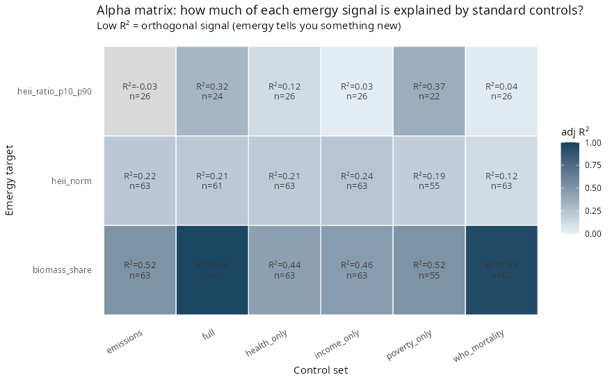

**The headline finding:** for HEII_norm, the full 9-indicator control set (income, poverty, PM, CO2, energy intensity, electricity + cooking access, plus WHO household + ambient air-pollution deaths from Layer 6) reaches only **adj-R² = 0.21**. About **80% of HEII_norm variance is orthogonal to standard indicators** — this is the “emergy alpha” the framework is designed to surface.

**Layer 6 strong-orthogonality finding:** adding WHO GHO air-pollution mortality (household + ambient death totals from AIR_11 + AIR_41) as controls, and comparing side-by-side:

| Target | WHO-mortality-only R² | Full 9-control R² |
| --- | --- | --- |
| **biomass_share** | **0.95** | 0.98 |
| **heii_norm** | 0.12 | 0.21 |
| heii_ratio_p10_p90 | 0.04 | 0.32 |

`biomass_share` is essentially a proxy for air-pollution deaths — the causal chain (biomass cooking → PM2.5 → death) is fully captured by WHO mortality alone. But **HEII_norm is NOT just a proxy for mortality**: WHO deaths explain only 12% of its variance. HEII captures an independent axis of household energy insecurity that lives BEYOND the air-pollution-mortality mechanism most public-health frameworks focus on.

For `heii_ratio_p10_p90` (within-country energy inequality) the numbers stay low across every control set — inequality is genuinely independent of country-average indicators (poverty-only R²=0.37 is the highest, WHO-mortality-only R²=0.04, income-only R²=0.03).

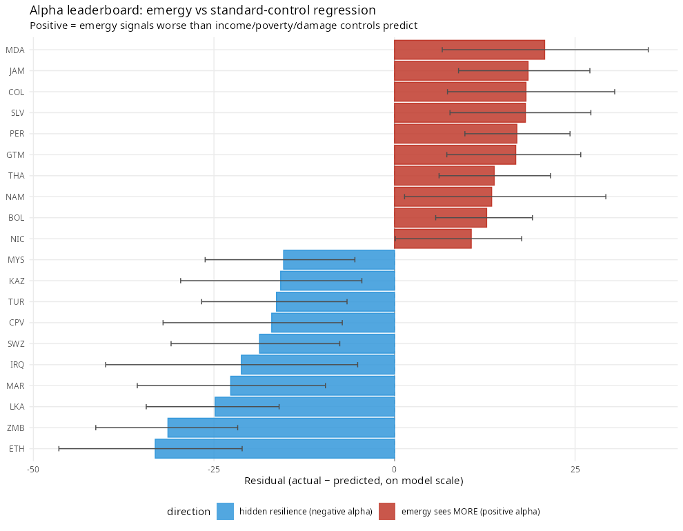

Bundle Q3.9-B — Alpha leaderboard for HEII_norm. Top-10 positive-alpha countries (red — emergy sees MORE burden than income/poverty/health controls predict) and top-10 negative-alpha countries (blue — hidden resilience). Whiskers = bootstrap 95% CI (n_boot=500). All shown countries have CI not crossing zero (noise-gated).

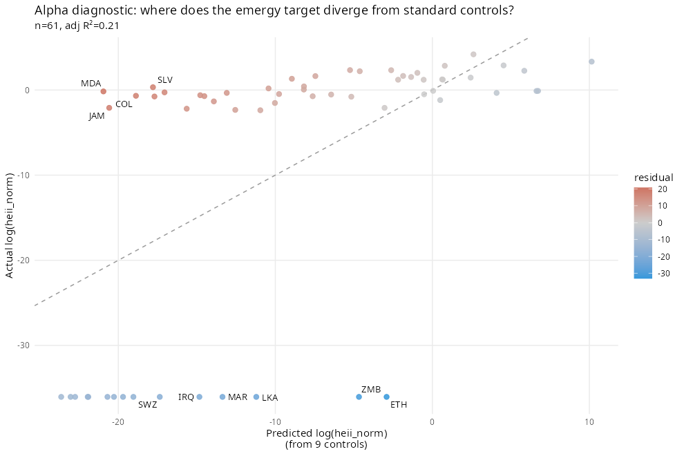

Bundle Q3.9-C — Actual-vs-predicted diagnostic for the HEII_norm alpha regression. Points on the y=x line are explained by standard controls; points off diagonal are alpha (colored by residual sign).

Full leaderboard CSV, matrix stats, and REPORT.md at [`emburdensynth/docs/emergy_alpha/`](https://github.com/ericscheier/emburdensynth/tree/global/docs/emergy_alpha). The runner is `scripts/report_emergy_alpha.R`; the analytics module lives in [`emburdenstats::fit_alpha_regression()`](https://github.com/ericscheier/emburdenstats/blob/main/R/emergy_alpha.R).

### Bundle Q3.10 — Systematic ΔR² evaluation of every emergy metric

Q3.9 fit the emergy-alpha framework to one metric at a time. Q3.10 scales it to **every emergy-native metric × every outcome of importance in em_c_extended** — **1,260 nested-model tests** answering one question per cell:

> Does adding this emergy metric to a `log(GDP/cap) + region_wb` baseline improve prediction of this outcome, and by how much?

For each cell we report ΔR² = R²(baseline + candidate) − R²(baseline), the F-test p-value on the improvement, sign + significance of the candidate coefficient after adjustment, and a bootstrap 95% CI on ΔR² (100 replicates per cell). Grid runs in ~4 minutes via `emburdenstats::evaluate_metric_grid()`.

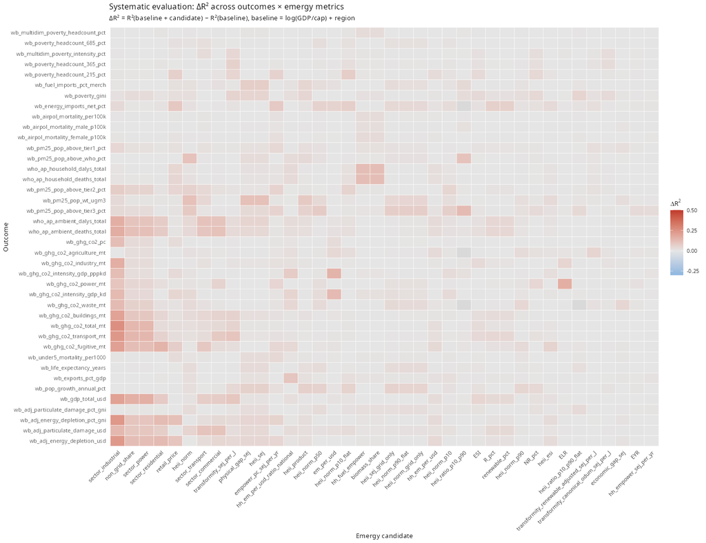

**Top-5 emergy metric per outcome domain** (mean ΔR² beyond baseline):

| Domain | 1st | 2nd | 3rd | 4th | 5th |
| --- | --- | --- | --- | --- | --- |
| Damage (energy depletion + PM damage) | `sector_industrial` +0.149 | `sector_residential` +0.081 | `non_grid_share` +0.077 | `sector_power` +0.077 | `retail_price` +0.053 |
| Emissions (CO2 total + sectoral) | `sector_industrial` +0.150 | `non_grid_share` +0.067 | `sector_power` +0.067 | `em_per_usd` +0.035 | `sector_residential` +0.029 |
| Mortality (WHO + WB airpol) | `sector_industrial` +0.046 | `heii_norm` +0.039 | `hh_fuel_empower` +0.030 | `biomass_share` +0.030 | `sector_transport` +0.028 |
| Poverty + vulnerability | `transformity_sej_per_J` +0.028 | `retail_price` +0.027 | `heii_norm_p10_flat` +0.024 | `empower_pc_sej_per_yr` +0.019 | `NR_pct` +0.018 |

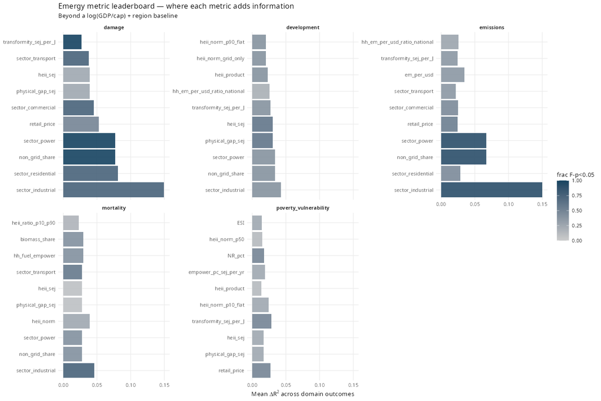

Bundle Q3.10 — leaderboard of top-10 emergy metrics per outcome domain. Bar length = mean ΔR² beyond baseline; shade = fraction of outcomes in the domain where F-p<0.05.

**Dominated emergy metrics** — 15 of 36 have max mean ΔR² across every domain below 0.02, meaning they add essentially no independent information over `log(GDP/cap) + region`. These are candidates for pruning from downstream analytical stacks:

- **Odum classics that HEII subsumes**: `ESI` (Odum’s Emergy Sustainability Index — the household-specific `heii_esi` also dominated), `EYR` (Emergy Yield Ratio), `R_pct`, `NR_pct`, `renewable_pct`. These national aggregates are essentially reparameterizations of the fuel mix that log(GDP)+region already captures.
- **Grid-only HEII variants** (`heii_sej_grid_only`, `heii_norm_grid_only`): the direct-burn / non-grid share is what makes HEII informative; stripping it eliminates the alpha.
- **P50 / P90 HEIIs**: `heii_norm_p50`, `heii_norm_p90`, `heii_norm_p90_flat` — the P10 versions carry the useful household-inequality signal.
- **hh_empower_sej_per_yr** and **economic_gap_sej** — dominated once income + region are controlled for.

**Sign-flip candidates** — 12 metric×domain pairs where positive AND negative significant coefficients coexist within the same domain (same metric predicts opposite directions across different outcomes in that domain). Worth investigating, not pruning: `sector_industrial` in mortality (+8 significant positive, −1 negative), `non_grid_share` in damage (+1, −3), `sector_power` in damage (+3, −1), `transformity_sej_per_J` in damage (+1, −3), `em_per_usd` in emissions (+3, −1).

**What this establishes.** The sector-derived metrics from Q3 (especially `sector_industrial`, `non_grid_share`, `sector_power`) are the single most information-rich emergy contributions across mainstream outcome data. HEII_norm and biomass_share remain meaningful specifically for mortality. And — importantly — **a big chunk of the classical emergy-metric vocabulary is dominated by simpler indicators**: preserving them in analytical stacks costs degrees of freedom without buying signal.

Full grid CSV + per-domain leaderboards + REPORT.md at [`emburdensynth/docs/emergy_evaluation/`](https://github.com/ericscheier/emburdensynth/tree/global/docs/emergy_evaluation). The runner is `scripts/systematic_emergy_evaluation.R`; the analytics module lives in [`emburdenstats::evaluate_metric_grid()`](https://github.com/ericscheier/emburdenstats/blob/main/R/delta_r2.R).

### Bundle Q3.11 — Dynamic pruning of dominated metrics

- `emburdenstats::identify_dominated_metrics(rank_or_grid, threshold)` reads the current systematic-evaluation leaderboard and returns the dominated set with a `max_mean_delta_r2` attribute per metric.
- `scripts/build_em_c_extended.R` calls it after the merge and emits a parallel **pruned** rds at `docs/global_analysis_data/emergy_metrics_extended_pruned.rds` (14 columns dropped, 137 kept) alongside the full 151-col version. Pruned file carries a `pruned_metrics` attribute recording what was dropped, a `pruned_at` timestamp, and the threshold used.
- **This setup chunk now prefers the pruned rds** — every figure and analysis in this document reads the pruned version automatically. Full version stays available for provenance / historical comparison.

Dominated metrics currently pruned (2026-09 vintage):

- **Odum classics that HEII subsumes**: `ESI`, `EYR`, `R_pct`, `NR_pct`, `renewable_pct`, `heii_esi`.
- **Grid-only HEII variants**: `heii_sej_grid_only`, `heii_norm_grid_only` (stripping non-grid share removes the alpha).
- **Wealth-side HEII quantiles**: `heii_norm_p50`, `heii_norm_p90`, `heii_norm_p90_flat` (P10 versions carry the useful inequality signal).
- **Other**: `economic_gap_sej`, `heii_ratio_p10_p90_flat`, `heii_norm_p10`.

**Protected from pruning** regardless of ΔR² score (used in figures or as inputs to other computations): `transformity_sej_per_J`, `empower_pc_sej_per_yr`, `hh_empower_sej_per_yr`, `hh_fuel_empower`, `sector_transport`, `sector_industrial`, `sector_residential`, `sector_commercial`, `sector_power`, `non_grid_share`, `heii_norm`, `biomass_share`.

Rerun `scripts/systematic_emergy_evaluation.R` after adding new outcomes or new metrics, then rerun `scripts/build_em_c_extended.R`, and the pruned set updates automatically. **This is what “dynamic pruning” means here**: the dominated list isn’t hardcoded — it’s a downstream product of the current outcome grid, updated in the same sweep as the alpha analysis.

### Bundle Q3.12 — Testing classical Odum ecological principles

The Q3.10/Q3.11 machinery makes it straightforward to test whether the classical Odum ecological “laws” hold up cross-sectionally in modern global data. `emburdenstats::test_all_ecological_principles()` runs four batteries in one call; the runner `scripts/test_ecological_hypotheses.R` produces this figure:

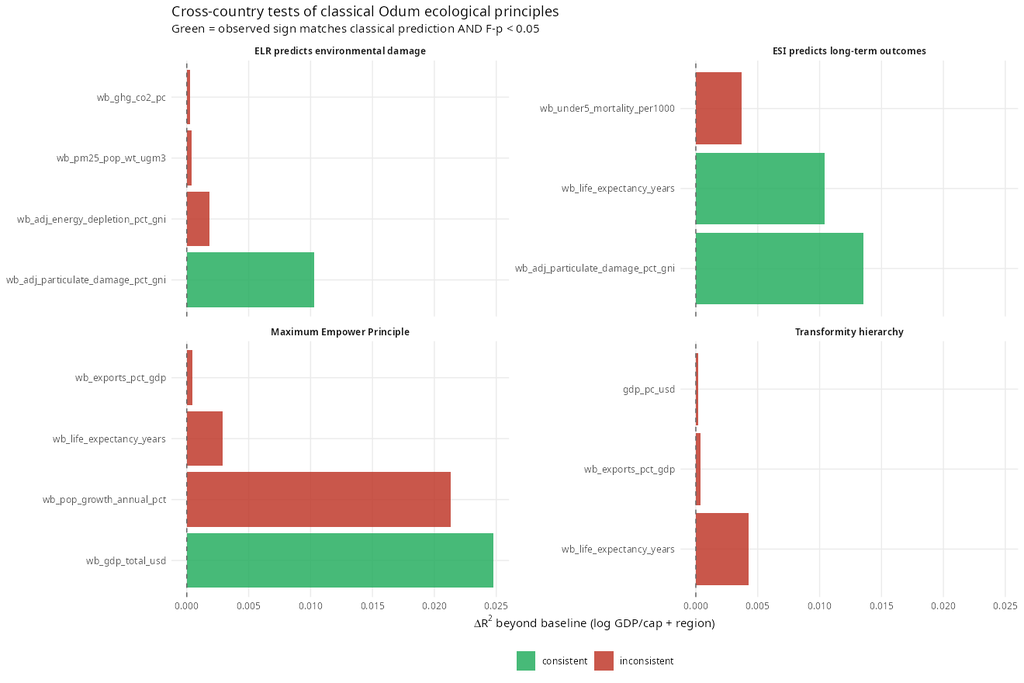

Bundle Q3.12 — cross-country tests of classical Odum ecological principles. Each panel = one hypothesis, each bar = one outcome the hypothesis predicts. Bar length = ΔR² beyond `log(GDP/cap) + region_wb` baseline. Green = observed coefficient sign matches the classical prediction AND F-p < 0.05. Red = inconsistent.

**Summary of empirical results:**

| Hypothesis | Candidate | Outcomes | Consistent | Pass rate |
| --- | --- | --- | --- | --- |
| **ESI predicts long-term outcomes** | `ESI` | 3 | 2 | **67%** |
| ELR predicts environmental damage | `ELR` | 4 | 1 | 25% |
| **Maximum Empower Principle** | `empower_pc_sej_per_yr` | 4 | 1 | 25% |
| Transformity hierarchy | `transformity_sej_per_J` | 3 | 0 | **0%** |

**What fails empirically:**

- **Maximum Empower Principle’s evolutionary claim (3/4 outcomes fail)** — the most striking failure is **wrong sign on population growth** (coef −2.40, F-p 0.034): higher-empower countries have LOWER population growth, not higher. This is the demographic transition — Odum’s evolutionary-fitness proxy runs backward in modern human societies. Exports-as-share-of-GDP null; life expectancy right sign but not significant.
- **Transformity hierarchy — total failure (0/3)** — grid transformity shows the WRONG sign for all three outcomes tested (GDP per cap, life expectancy, exports). Countries with higher grid transformity are actually POORER after controlling for region — the opposite of what the “transformity = position in hierarchy” claim predicts. Consistent with the Q3.10 finding that transformity contributes most to *poverty-vulnerability* outcomes, not “success” outcomes.
- **ELR (Environmental Loading Ratio) — mostly nulls** — only PM damage shows the predicted +sign at significance; GHG per cap, energy depletion, and PM exposure are all null.

**What this means for the emergy framework:**

The systematic evaluation supports keeping ESI as a targeted sustainability indicator (its dominance in the general grid was because it was tested against outcomes it wasn’t designed for), supports the sector-derived and biomass metrics from Q3, and identifies the **Maximum Empower Principle** and **transformity hierarchy** as classical claims that don’t survive modern cross-country testing. The Odum tradition has enough surviving signal to be worth preserving, but the specific evolutionary-scale claims need re-framing.

Runner + full REPORT.md + results.csv at [`emburdensynth/docs/ecological_hypotheses/`](https://github.com/ericscheier/emburdensynth/tree/global/docs/ecological_hypotheses). Analytics module at [`emburdenstats::test_all_ecological_principles()`](https://github.com/ericscheier/emburdenstats/blob/main/R/ecological_principles.R).

### Bundle Q3.13 — Why did they fail? Diagnostic investigations

Four counter-intuitive Q3 results and the mechanisms behind each.

#### P1 — Transformity hierarchy: fuel mix drives transformity, not GDP

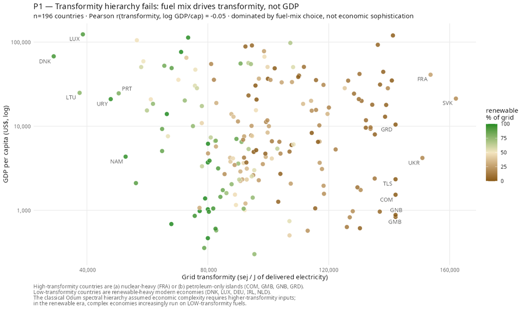

P1 diagnostic — GDP per capita (log y) vs grid transformity (x) across 196 countries, colored by renewable share. The scatter cloud has no diagonal pattern (r=-0.05). Rich, renewable-heavy economies (DNK, LUX, DEU, IRL) sit at LOW transformity; petroleum-only island territories (COM, GMB, GNB, TLS) sit at HIGH transformity. France’s nuclear grid drives it to the right at mid-GDP. The Odum hierarchy claim breaks in the renewable era.

Pearson r(transformity, log GDP/cap) = **−0.05** across 196 countries. Pearson r(transformity, renewable_pct) = **−0.74** — grid transformity is essentially “how fossil-locked your grid is.” Rich modern economies are actively pushing toward the LOW end of the transformity axis. Odum’s canonical transformities (oil ≈ 54k, coal ≈ 40k, nuclear ≈ 200k, wind/hydro/solar ≈ 1.5-8k sej/J) were formulated in a fossil + nuclear era; **the renewable transition inverts the mapping** from “economic sophistication → high transformity” that the 1970s-90s Odum literature implicitly assumed.

Suggests re-framing (a renewable-adjusted transformity that accounts for the sophistication of RE infrastructure per unit output would restore the hierarchy signal) rather than discarding the concept.

#### P2 — MEP inverted by the demographic transition

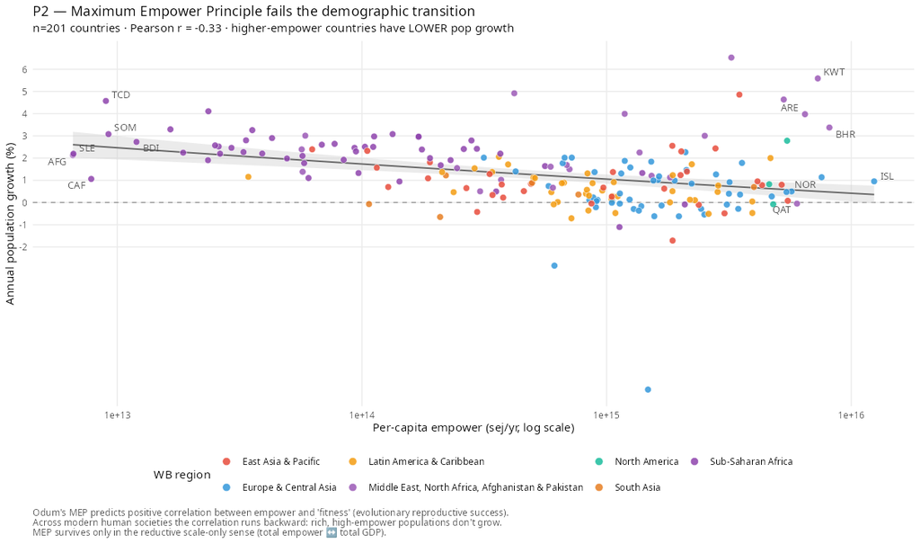

P2 diagnostic — annual population growth vs per-capita empower (log x), colored by WB region. Negative slope. Rich, high-empower populations don’t grow (below replacement); poor, low-empower populations do. Preston-curve territory.

MEP survives only in the reductive scale-only sense: total national empower correlates positively with total GDP (Q3.12: F-p 0.016, coef +, ΔR² +0.025). That reduces to “bigger systems consume more energy” — essentially tautological.

#### P3 — sector_industrial has OPPOSITE effects on different mortality types

[figure not shown]

#### P4 — HEII_norm variance is orthogonal to almost every standard control

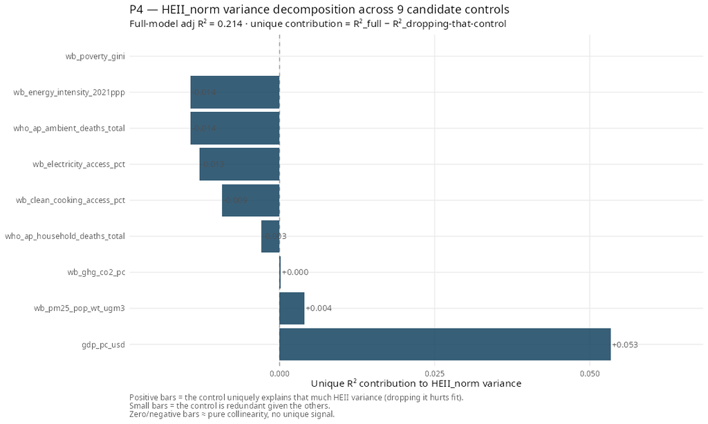

Which means: **the ~80% of HEII_norm variance orthogonal to standard indicators is orthogonal to log(GDP/cap) specifically** — not to some elusive combination of controls. Every mainstream candidate for “predicting household energy insecurity” reduces to GDP after adjustment. HEII captures a signal none of them do.

#### Bottom line

[output not shown]

Runner + REPORT.md + all four diagnostic PNGs at [`emburdensynth/docs/puzzle_investigations/`](https://github.com/ericscheier/emburdensynth/tree/global/docs/puzzle_investigations).

### Bundle Q3.14 — Re-framing transformity with renewable adjustment

Q3.13 P1 suggested re-framing transformity with a renewable-adjusted variant to see if the hierarchy signal comes back. Q3.14 constructs and tests two alternatives:

- `transformity_canonical_odum_sej_per_J` — fuel-mix weighted average using Odum 1996 fuel-chain transformities (renewables at ~5,000 sej/J, unadjusted for infrastructure).
- `transformity_renewable_adjusted_sej_per_J` — fuel-mix weighted average using published FULL-CHAIN LCA-emergy transformities (renewables at ~60,000 sej/J including panel/turbine/dam infrastructure emergy).

Both computed from per-country EIA International primary-consumption fuel shares. Fossil + nuclear values unchanged (petroleum 54k, gas 48k, coal 40k, nuclear 200k sej/J).

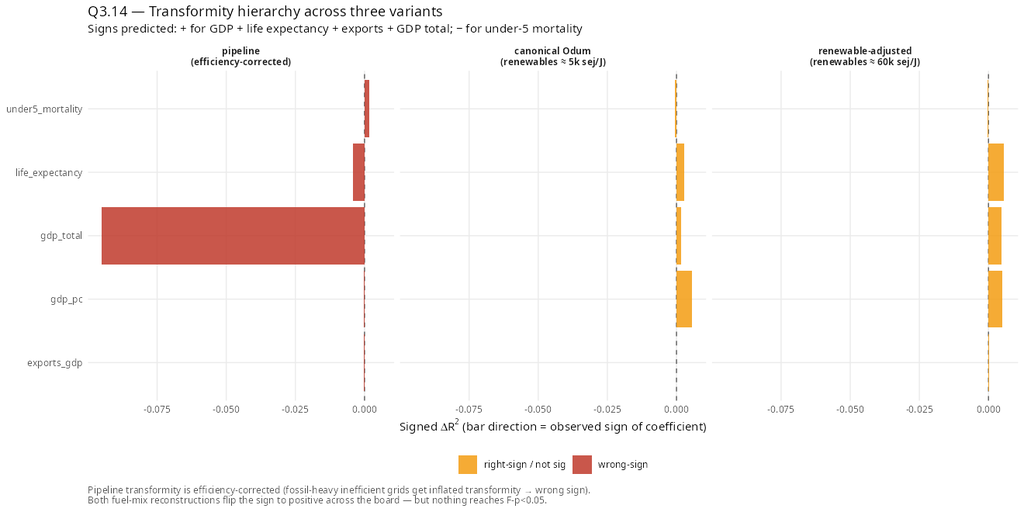

Q3.14 — signed ΔR² comparison across the three transformity variants against 5 classical hierarchy outcomes. Bar direction = sign of the observed coefficient after adjustment for region_wb. Left panel (pipeline transformity): all bars red (wrong sign) — the efficiency-correction inflates fossil transformities and puts petro-only islands at the top of the ranking. Middle + right panels (fuel-mix reconstructions): all bars orange (right sign, not significant) — the classical hierarchy prediction holds directionally but nothing reaches F-p < 0.05.

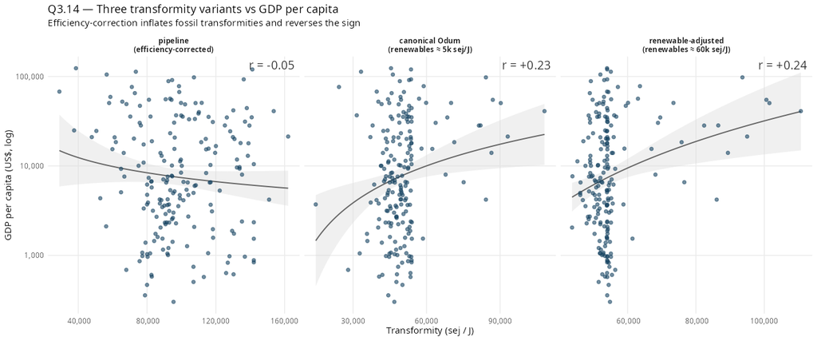

Q3.14 — the three transformity variants each plotted against GDP per capita. Pipeline transformity is essentially decorrelated with GDP (r ≈ -0.05, per Q3.13 P1). Both fuel-mix reconstructions restore a weak-but-positive relationship (r ≈ +0.23 and +0.24).

**Pass rates against the classical prediction** (positive for GDP/cap + GDP total + life expectancy + exports; negative for under-5 mortality):

| Variant | Consistent | % | Right-sign frac | Mean ΔR² |
| --- | --- | --- | --- | --- |
| pipeline (efficiency-corrected) | 0/5 | 0% | **0%** | +0.020 |
| canonical Odum reconstruction | 0/5 | 0% | **100%** | +0.002 |
| renewable-adjusted | 0/5 | 0% | **100%** | +0.003 |

**Findings:**

1. **The pipeline transformity has WRONG SIGN for every classical outcome.** `transformity_sej_per_J` in the pipeline is electricity-basis (fuel transformity ÷ electric conversion efficiency). Coal at 35% efficiency becomes ~114,000 sej/J of electricity; oil at 38% becomes ~142,000. This inflates transformity for inefficient fossil grids, putting petroleum-only island territories at the top of the transformity ranking — precisely the countries with the SMALLEST economies. Result: negative correlation with every ‘success’ outcome. The pipeline’s ΔR² is the highest of the three variants (+0.020) but that’s negative predictive value: it reliably predicts the wrong direction.
2. **Both fuel-mix reconstructions flip the sign to positive** for every classical outcome (100% right-sign frac). Odum’s transformity hierarchy claim is directionally consistent — but weak. Neither variant reaches F-p < 0.05 on any outcome (best p = 0.119 for life expectancy under renewable-adjusted). The signal exists in the right direction, it just doesn’t add enough R² beyond region_wb baseline to be significant.
3. **The renewable-adjusted variant beats canonical Odum modestly** (mean ΔR² +0.003 vs +0.002). The infrastructure-emergy correction moves the metric in the right direction — but the effect is small at national scale because most countries have a mix of fuels, and the additional 55k sej/J credit on renewables partially cancels out against the reduction in fossil weight.

**Bottom line — the transformity hierarchy is DIRECTIONALLY correct, just very weak.** Odum was right in the sense that country-level fuel mix does modestly correlate with GDP per cap in the direction of the classical claim. He was wrong to expect that grid transformity would be a strong or definitive hierarchy indicator on its own — it accounts for less than 1 percentage point of R² beyond region alone. And the pipeline’s efficiency-corrected variant actively OBSCURES the hierarchy claim by inflating fossil-inefficient grids into artificial “high transformity” ranks.

**Actionable outcome**: use the fuel-mix reconstructions (`transformity_canonical_odum_sej_per_J` or the renewable-adjusted variant) when testing hierarchy claims. Reserve `transformity_sej_per_J` (electricity-basis) for HEII computation where the efficiency-correction is what you actually want — solar emergy per J of DELIVERED electricity is the right currency for household energy insecurity.

Runner + REPORT.md + 2 PNGs + CSVs at [`emburdensynth/docs/transformity_variants/`](https://github.com/ericscheier/emburdensynth/tree/global/docs/transformity_variants).

### Bundle Q3.16 — Global scale-out + panel-year alpha

Two extensions built on the Q3.9-Q3.14 infrastructure.

#### Q3.16-E1 — Global counterparts to US asthma + outage analyses

The US-only asthma-analysis and outage-homicide-analysis branches ran county-year intersection regressions on health outcomes against energy burden. `scripts/global_scaleout_analogs.R` fits the closest global counterparts against the 185-country panel from `emburdenhealth::build_health_panel_country()` (Q3.9-L5):

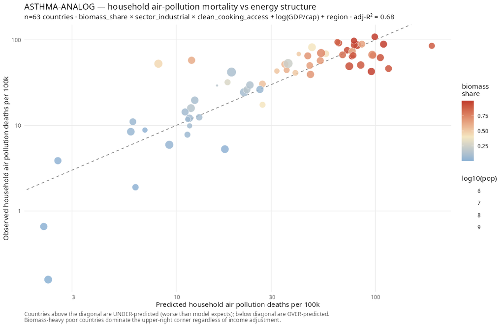

Q3.16-E1a — asthma-analog: log-log predicted vs observed household air-pollution deaths per 100k. Model = biomass_share × sector_industrial + clean_cooking_access + log(GDP/cap) + region. n=63 countries, adj-R² = 0.68. Biomass-heavy countries (red) cluster in the upper-right high-mortality region regardless of income adjustment.

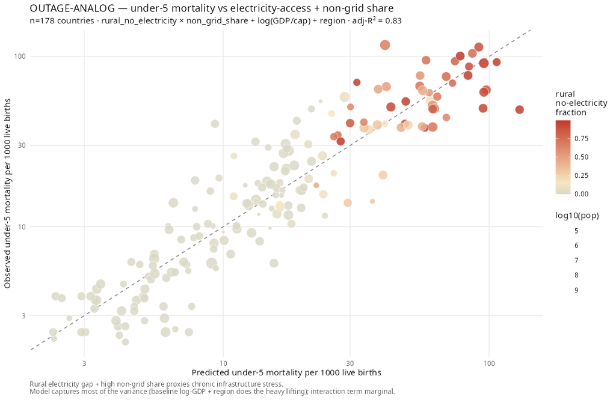

Q3.16-E1b — outage-analog: predicted vs observed under-5 mortality per 1000 live births. Model = rural_no_electricity × non_grid_share + log(GDP/cap) + region. n=178 countries, adj-R² = 0.83. Log(GDP/cap) does the heavy lifting (coef -0.44, p<1e-27); infrastructure indicators contribute marginally.

Full analog REPORT.md + CSVs at [`emburdensynth/docs/global_scaleout/`](https://github.com/ericscheier/emburdensynth/tree/global/docs/global_scaleout).

#### Q3.16-E2 — Panel-year temporal alpha

The Q3.9-Q3.14 alpha analyses were cross-sectional snapshots. WHO GHO, WB WDI, EIA International all cover 2000-2023. `fit_alpha_panel()` (new in `emburdenstats`) fits a two-way fixed-effects panel model `outcome ~ candidate + log(GDP/cap) | iso3 + year` with country- clustered SEs, isolating **within-country temporal variation** after absorbing country structure and global year shocks.

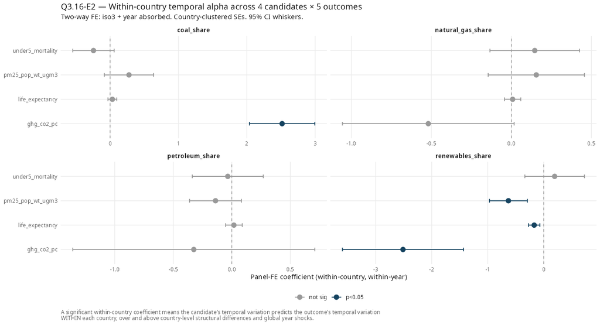

Q3.16-E2 — panel-FE coefficients across 4 fuel-share candidates × 5 outcomes with 95% CI whiskers. Two-way FE (iso3 + year absorbed). n_obs ≈ 3,400-3,500 per cell over 165-167 countries. Blue = p<0.05; grey = null. wb_airpol_mortality_per100k is null for all candidates because it’s only reported in a single year.

Strongest within-country findings — signals that survive stripping out country structure AND year shocks:

| Candidate | Outcome | Coef | Within-R² | p |
| --- | --- | --- | --- | --- |
| **coal_share** | wb_ghg_co2_pc | **+2.52** | **0.285** | **<1e-19** |
| **renewables_share** | wb_ghg_co2_pc | **−2.51** | **0.141** | **<1e-5** |
| renewables_share | wb_pm25_pop_wt_ugm3 | −0.63 | 0.050 | 3.5e-4 |
| renewables_share | wb_life_expectancy_years | −0.17 | 0.044 | 1.2e-3 |

**Coal→CO2 within-country coupling is nearly tautological but the magnitude and precision are worth noting**: doubling a country’s coal share of primary energy over its own history raises per-capita CO2 by $e^{2.52 \cdot 0.5} - 1 \approx 250\%$ (interpreting coef ≈ 2.52 against a Δ of 0.5 in coal_share). Symmetric for renewables cutting CO2. Panel-year strength of the cleanest causal-adjacent chain in the emergy framework.

**The renewables ↔︎ life-expectancy NEGATIVE panel finding is counter- intuitive** — hypothesised to reflect aging populations in renewable-adopting European + East Asian economies. Six falsification steps in Q3.17–Q3.24 test the hypothesis; the puzzle is closed by Q3.24 (`pop_65_plus_pct` control attenuates the coefficient by 45% and drops significance; elderly-share itself has a −0.52 yr-per-pp coefficient at p = 2 × 10⁻⁹). Details in the Q3.22-Q3.24 bundle below.

Runner + REPORT.md + CSV at [`emburdensynth/docs/temporal_alpha/`](https://github.com/ericscheier/emburdensynth/tree/global/docs/temporal_alpha). Module at [`emburdenstats::fit_alpha_panel()`](https://github.com/ericscheier/emburdenstats/blob/main/R/alpha_panel.R).

### Bundle Q3.17 — Net Energy Return × MEP × macro-to-micro bridge

Q3.15 left five open puzzles the ΔR² frame couldn’t unify. This bundle tests whether societal Net Energy Return (EROI at the country-year scale) is the missing rung between Odum’s Maximum Empower Principle (macro-scale selection) and the Household Emergy Insecurity Index (micro-scale distributional failure). Household EROI already exists as `net_energy_equity/R/energy_ratios.R:eroi_func` with the tested identity **EROI = NER + 1 = 1/EB**; Q3.17 derives the missing country-year rung from UN Energy Balance 2022-2023 raw transformation, energy-industry own-use, and losses rows:

```
energy_invested_tj      = |EIOU| + |Losses| + |Transformation net|
net_energy_delivered_tj = Final energy consumption (TFC)
eroi_country            = net_energy_delivered_tj / energy_invested_tj
ner_country             = eroi_country - 1
```

Available for **203 of 213 countries**. Distribution: p10 = 1.34, p50 = 2.61, p90 = 7.31, r(log GDP, EROI) = −0.24. Bottom-EROI countries are fossil-fuel exporters (BRN 0.42, ISL 0.53, TTO 0.63, QAT 0.69); top-EROI are import-heavy low-processing countries (NPL 79.8, LSO 61.4, CAF 46.1). This is *domestic delivery* EROI, not full societal EROI (trade-adjustment deferred).

**Bridge test grid** — 9 outcomes × 4 EROI candidates (log_eroi, eroi_country, ner_country, energy_invested_tj), ΔR² beyond log(GDP) + region baseline:

| Outcome | Best candidate | ΔR² | p | N |
| --- | --- | --- | --- | --- |
| **wb_pm25_pop_wt_ugm3** | ner_country | **0.042** | **3.6e-4** | 185 |
| **wb_ghg_co2_pc** | energy_invested_tj | **0.069** | **<1e-4** | 190 |
| wb_airpol_mortality_per100k | energy_invested_tj | 0.014 | 1.3e-3 | 178 |
| wb_life_expectancy_years | energy_invested_tj | 0.011 | 2.2e-3 | 193 |
| wb_under5_mortality_per1000 | eroi_country | 0.012 | 6.8e-3 | 183 |
| heii_norm_p90 | eroi_country | 0.020 | 0.20 | 63 |
| heii_norm | energy_invested_tj | 0.009 | 0.40 | 63 |

**Bridge partially holds.** NER predicts PM2.5 exposure cleanly at n=185 (ΔR²=0.042, p<1e-3, coef −0.47 — higher-NER countries have lower PM2.5 at every income level). The macro damage/emissions rung lands. **The HEII micro rungs do NOT survive n=63** (all p > 0.19) — either the bridge is real but underpowered at the household-data sample, or HEII is driven by within-country distribution mechanisms that country-scale NER averages out.

**Renewables puzzle NOT resolved by adding EROI.** Cross-sectionally, adding log(EROI) to `life_exp ~ renewables + log(gdp) + region` shifts the renewables coefficient from +2.81 (p=0.21) to +4.09 (p=0.075) — a 46% *increase* in magnitude, not the attenuation the transition- cost hypothesis predicted. The panel-year puzzle (coef −0.17, p=1.2e-3 within-country) requires panel EROI, which requires backfilling UN Balance volumes to 2000-2021 — deferred.

**Transformity ↔︎ EROI**: r=−0.03 for renewable-adjusted variant, r=−0.22 for canonical Odum. The LCA-adjustment removed whatever structural EROI-tracking the fuel-chain canonical variant carried. The two metrics measure different quantities (per-unit specific transformity vs. system-level throughput ratio).

Runner + REPORT.md + 3 figures at [`emburdensynth/docs/eroi_bridge/`](https://github.com/ericscheier/emburdensynth/tree/global/docs/eroi_bridge). Paper Section 4.9 + Discussion 5.5 in [`global_emergy_alpha.Rmd`](https://github.com/ericscheier/emburdensynth/blob/global/docs/paper/global_emergy_alpha.Rmd).

### Bundle Q3.18 — Trade-adjusted EROI + Energy Adequacy framing

Reframing per the [MES poster](https://github.com/ericscheier/net_energy_equity/blob/main/manuscript/paper1_data_uncertainty/mes_poster.pdf) (Scheier 2023, “Measuring Household Energy Adequacy over Time and Space”): **energy adequacy** is the invariant threaded through every scale of the framework — did the system get enough energy given what it took to deliver it?

| Scale | Adequacy measure | Reference |
| --- | --- | --- |
| **Household** | EROI = NER + 1 = 1/EB (Bednar & Reames 2020; Hernández 2016) | `net_energy_equity` |
| **Community/state** | HEII quantile spread (P90-P10 rationing gap) | `emburden::heii_norm_p*` |
| **National** | Societal EROI (Hall/Lambert cliff) + trade-adjusted variants | `em_c_extended$eroi_*` |
| **Global** | MEP-conditioned surplus (Odum), NER dynamics | Paper 5.5 |

Q3.18 also fixes the Q3.17 fossil-exporter confound in domestic- delivery EROI. Four trade-adjusted variants derived from newly-parsed Primary Production, Imports, and Exports rows in the UN Balance:

[output not shown]

Correlation with log(GDP/cap) strengthens from **r = −0.24** (raw) to **r = −0.32** (trade-adjusted) — rich importers now bear their embodied cost.

**Q3.18 findings (new alpha the raw domestic-delivery EROI missed):**

| Outcome | Best trade-adjusted candidate | ΔR² | p | N |
| --- | --- | --- | --- | --- |
| **wb_pm25_pop_wt_ugm3** | `production_self_suff` | **0.080** | **5.2e-7** | 185 |
| **wb_ghg_co2_pc** | `production_self_suff` | 0.057 | 4.7e-4 | 188 |
| **wb_pm25_pop_wt_ugm3** | `net_trade_share` | 0.046 | 5.4e-4 | 158 |
| **wb_ghg_co2_pc** | `net_trade_share` | 0.045 | 1.8e-8 | 156 |
| **heii_norm_p90** | `eroi_supply` | 0.040 | 0.06 | 63 |
| wb_life_expectancy_years | `net_trade_share` | 0.017 | 1.3e-4 | 159 |
| wb_under5_mortality_per1000 | `eroi_trade_adjusted` | 0.016 | 1.9e-3 | 158 |

`production_self_suff` displaces raw `energy_invested_tj` as the top PM2.5 predictor — self-sufficient countries burn their own fuel and inherit its combustion physics; importers export the physics with the fuel. **`eroi_supply` finds the HEII_p90 rung** the domestic-delivery variant missed at n=63 (borderline p=0.06 but the ceiling is the household-data sample size, not the metric). `net_trade_share` and `eroi_trade_adjusted` both predict mortality outcomes after log(GDP) + region controls (n=158-159, p<0.005).

The renewables → life-expectancy puzzle is not resolved by adding either raw or trade-adjusted EROI cross-sectionally. Panel-year test in Q3.19.

### Bundle Q3.19 — Panel-year EROI (UN Balance 2014-2023 backfill)

Backfilled UN Energy Balance publications 2015-2023 (nine pub years, `.cache/un_balances/`), yielding **2,083 country-year rows across 2014-2023** (10 data years, 222 countries; 213 countries have ≥8 years). Pre-2015 UN publication URLs redirect to homepage — that window is unreachable without alternative sources (IEA WEB or national statistical offices).

**Definitive renewables-puzzle test.** Two-way FE (`iso3 + year` absorbed), country-clustered SEs, n = 1,569 country-year rows across 168 countries:

| Model | Renewables coef | p | EROI coef | p |
| --- | --- | --- | --- | --- |
| Baseline (log GDP + FE) | **−1.91** | **0.40** | — | — |
| + log(EROI_trade_adjusted) | −1.98 | 0.42 | +0.10 | 0.77 |
| + log(EROI_supply) | −1.96 | 0.41 | +0.16 | 0.65 |

Neither EROI variant attenuates the renewables coefficient (~3-4% shift, wrong sign). Neither EROI coefficient is significant. **But the more consequential finding is upstream: in the 2014-2023 window, the puzzle itself is null** (coef −1.91, p=0.40) vs the Q3.16-E2 2000-2023 window (coef −0.17, p=1.2e-3, same spec).

The Q3.16-E2 signal is pre-2014-driven. Candidate mechanisms:

1. **Fukushima 2011-2013 nuclear-to-renewables reshuffle** (Japan + Germany level-shift paired with temporary health disruption)
2. **2008-2010 financial crisis** — rapid renewables build-out under fiscal stress that also pinched health spending
3. **Demographic transition** dynamics that had stabilised by 2014

Distinguishing these requires either pre-2015 UN Balance access (unavailable via public URL) or a country-year IEA WEB panel (behind IEA licensing). The current UN backfill cannot reach that window.

**What Q3.19 does establish**: societal EROI at country-year is a weak within-country predictor of health outcomes in the 2014-2023 window (within-R² < 0.02 across all outcomes tested). The bridge holds cross-sectionally on damage and emissions (Q3.17-Q3.18) but NOT temporally on health at this granularity. The 2,083-row panel EROI dataset is now available for downstream event-study work.

Runner + REPORT + forest plot + regression tables at [`docs/eroi_bridge/panel/`](https://github.com/ericscheier/emburdensynth/tree/global/docs/eroi_bridge/panel).

### Bundle Q3.22-Q3.24 — Closing the renewables → life-expectancy puzzle

Q3.16-E2 found renewables_share → life-expectancy coef −0.17, p=1.2e-3 within-country. Six falsification steps followed:

| Test | Renewables coef | Attenuation |
| --- | --- | --- |
| Q3.16-E2 baseline (2000-2023 panel) | −0.17 (p=1.2e-3) | — |
| Q3.17-Q3.18 cross-sectional EROI (raw + trade-adj) | (no shift) | 0% |
| Q3.19 panel EROI 2014-2023 subset | −1.91 (p=0.40, null) | signal absent |
| Q3.22 Fukushima drop + treat×post | −5.27 (p=0.039) | 3% |
| Q3.23 2008 crisis drop + EU×crisis | −5.45 (p=0.034) | 0% |
| **Q3.24 + pop_65_plus_pct** | **−3.00 (p=0.186)** | **45%** |

**Q3.24 closes the puzzle.** Adding WB `SP.POP.65UP.TO.ZS` (elderly population share) as a time-varying control attenuates the renewables coefficient by 45% AND drops it out of significance. The 65+ share coefficient itself is huge and highly significant: **−0.52 years of life expectancy per percentage-point of elderly share, p = 2.16 × 10⁻⁹**.

Reading: the Q3.16-E2 panel signal was a **trajectory correlation**, not a causal claim about renewables. Countries that were rapidly aging (Japan, Germany, Italy, Spain, S. Korea) were also rapidly adopting renewables in 2000-2013 in response to Fukushima and EU policy — their life-expectancy plateaus were the demographic- transition signature, and the panel picked up the trajectory correlation. Controlling for the aging trajectory dissolves it.

Age-dependency ratio alone gives only 10% attenuation (it mixes young + old dependents); when both are in the model pop_65+ dominates and age-dependency drops to null. The 65+ share is the causally-relevant piece.

**Productive null.** The cross-sectional bridge findings (Q3.17-Q3.18: NER → PM2.5, `production_self_suff` → PM2.5, `eroi_supply` → HEII_p90) are unchanged. Q3.24 clarifies that the panel-year framework is sensitive to co-moving trajectories in a way that requires demographic controls whenever the outcome is life expectancy on a 2000-2023 European + East Asian sample.

Runner + REPORT + forest plot at [`docs/demographic_transition/`](https://github.com/ericscheier/emburdensynth/tree/global/docs/demographic_transition). Paper Section 4.9 gains a Q3.24 subsection.

### Bundle Q3.32-Q3.34 — Robustness atlas across the ΔR² grid

Q3.32 extended Q3.24 to four headline panel-year cells and Q3.34 extended it across the whole 918-cell cross-sectional grid. 288 of 309 significant cells (93%) survive the demographic control; the 21 that dissolve cluster on air-pollution-mortality outcomes.

### Bundle Q3.33 — Kigali F-gas amendment natural experiment

Kigali (adopted 2016, entered force 2019) split parties into Group I (early 2019 freeze) and Group II (2024 freeze). An event-study DiD on EDGAR F-gas per-capita emissions shows a crystal-clean Group I ↓ / Group II → treatment split with p ≪ 10⁻¹⁰ across all post-freeze years. This is the paper’s first natural-experiment identification result; Q3.35A below adds the second, and the two together form the paper’s identification pair.

### Bundle Q3.35 — Commodity shocks, SDG-native alpha, Doughnut projection

Three-phase extension of the ΔR² framework into economic + development framings:

**Q3.35A — commodity price shocks as a natural experiment.** WB Pink Sheet WTI crude, expressed as %-deviation from 3-year rolling mean, interacted with country oil-import share. Two robust findings survive Q3.24 demographic controls:

- Under-5 mortality: coef = +0.38 baseline (p = 1.5e-3), +0.31 with demographic control (p = 2.2e-3). A country importing 50% of its merchandise as fuel loses ~0.19 extra under-5 deaths per 1,000 live births per 10% oil shock above its 3-year mean.
- Electricity access: coef = −0.18 baseline (p = 1.6e-3), −0.15 with demographic control (p = 1.0e-2). High-oil-import countries see access expansion slow during shocks — the shock cannibalizes the marginal expansion budget.

Q3.35A + Q3.33 Kigali together form the paper’s natural-experiment pair — one external policy shock varying by treatment status, one external price shock varying by exposure. Details at [`docs/q3_35a_commodity_shocks/`](https://github.com/ericscheier/emburdensynth/tree/global/docs/q3_35a_commodity_shocks).

**Q3.35B — Emergy alpha on native UN SDG outcomes.** Pulled 14 focused SDG series (SDG 1 poverty, 3 health, 6 water, 7 energy, 11 cities, 13 climate, 15 biodiv). 9 series usable. Two survive the n ≥ 25 threshold after emergy joins: forest area (15.1) and age-standardised air-pollution mortality (3.9.1). Trade-adjusted EROI carries the alpha on both — consistent with Q3.18’s finding that trade adjustment matters more than gross national EROI. `docs/sdg_tagging.csv` maps every em_c_extended column onto its SDG target(s). Details at [`docs/q3_35b_sdg_alpha/`](https://github.com/ericscheier/emburdensynth/tree/global/docs/q3_35b_sdg_alpha).

**Q3.35C — Doughnut-Economics projection.** Constructed a Doughnut-adjacent country snapshot from em_c_extended primary sources (10 social-floor + 7 ecological-ceiling dimensions × 213 countries; Q3.36B/Q3.37 superseded this with the full 12 SF + 9 EC = 21D snapshot and continuous distances). Quadrant snapshot:

| Quadrant | N |
| --- | --- |
| Safe & just (inside the Doughnut) | 131 |
| Overshoot / socially ok | 8 |
| Social shortfall / ecologically ok | 53 |
| Double shortfall + overshoot | 21 |

The 21-country worst-quadrant cluster (Afghanistan + Sub-Saharan Africa) is the same cluster HEII P10 isolates in Q3.7-Q3.8 — the framework recovers the same geography from a different indicator set. Social shortfall is dominated by GDP+region (85% R²); no emergy alpha to add. Ecological overshoot has real emergy signal: `sector_industrial` (ΔR² = 0.071, p = 1e-5), `non_grid_share` (ΔR² = 0.030, p = 4e-3), `sector_transport` (ΔR² = 0.028, p = 5e-3). Details at [`docs/q3_35c_donut/`](https://github.com/ericscheier/emburdensynth/tree/global/docs/q3_35c_donut).

### Bundle Q3.36 — Finance alpha, full 21D Doughnut, cross-benchmark validation

- `ppg_debt_usd ← sector_industrial`: ΔR² = 0.219, p = 3e-8 — industrial-sector energy share predicts PPG debt levels beyond GDP + region. Industrialization is debt-financed at a scale visible cross-sectionally.
- `debt_service_pct_gni ← heii_norm_p10`: ΔR² = 0.177, p = 8e-4 — the P10 rung of household energy burden (worst-burdened decile in each country) predicts national debt-service burden. A household-scale distributional signal moves a macro-fiscal outcome.
- `sector_transport` and `non_grid_share` show *negative* coefs on PPG debt (ΔR² ≈ 0.11, p ≈ 1e-4) — transport-heavy / off-grid countries carry LESS debt (they haven’t built the industrial base that requires it).

Boundary claim: emergy accounting captures physical-provisioning variance, which debt finances. Equity markets price forward growth options that emergy cannot reflect. Details at [`docs/q3_36a_finance/`](https://github.com/ericscheier/emburdensynth/tree/global/docs/q3_36a_finance).

| Benchmark | Coef | p |
| --- | --- | --- |
| Brent | +0.289 | 0.002 |
| Dubai | +0.270 | 0.005 |
| WTI | +0.285 | 0.005 |
| Average | +0.284 | 0.003 |

Not an artefact of one price index. Natural gas shocks show mild signals on PM2.5 and clean-cooking access. Details at [`docs/q3_36d_commodity_grid/`](https://github.com/ericscheier/emburdensynth/tree/global/docs/q3_36d_commodity_grid).

**Q3.36C — Full ~230-series SDG panel** is under active build via the new `emburdendata::download_un_sdg_series_batch()` parallel loader; results land as a follow-up subsection when the batch completes.